# SSAMethodCode

Yakovlev D.M.

2023-06-07

# Список рукописных функций

```r
# Строит траекторную матрицу из временного ряда с длиной окна L
BuildTrajectoryMatrix<-function(timeSeries, L){

  timeSeries <- as.vector(timeSeries)

  # Длина окна не должна превосходить длину временного ряда
  if(length(timeSeries) <= L) stop("L parameter (window length) must be less than timeSeries length")


  K <- length(timeSeries) - L + 1

  # Инициализация траекторной матрицы
  matrixResult <- matrix(0, ncol = K, nrow = L)

  for (i in 1:K) {
    matrixResult[,i]<-timeSeries[i:(i+L-1)]
  }

  return(matrixResult)
}

# Функция диагонального усреднения
DiagonalAveraging <- function(x){
  x <- as.matrix(x)

  # Если длина окна больше числа окон - транспонируем матрицу
  if(dim(x)[1] > dim(x)[2]) x <- tr(x)

  L <- dim(x)[1] # Длина окна
  K <- dim(x)[2] # Число окон
  N <- L + K - 1 # Длина ряда

  print(paste("L = ", L, "K = ", K, "N = ", N))


  timeSeriesResult <- c()

  # Восстановление компоненты ряда (по формуле с тремя случаями)

  # Случай один
  for(i in 1:L){
    temporaryValue <- 0

    for(j in 1:i){
      temporaryValue = temporaryValue + x[j, i - j + 1]
    }

    timeSeriesResult[i] <- temporaryValue/i
  }

  # Случай два
  for(i in (L+1):K){
    temporaryValue <- 0

    for(j in 1:L){
      temporaryValue = temporaryValue + x[j, i - j + 1]
    }

    timeSeriesResult[i] <- temporaryValue/L
  }

  # Случай три
  for(i in (K+1):N){
    temporaryValue <- 0

    for(j in (i - K + 1):L){
      temporaryValue = temporaryValue + x[j, i - j + 1]
    }

    timeSeriesResult[i] <- temporaryValue/(N-i+1)
  }

  return(timeSeriesResult)
}

# Функция, возвращающая конечный ранг ряда в случае его существования
TimeSeriesFiniteRank <- function(timeSeries){

  N <- length(timeSeries)     # Длина ряда

  rnkCurr <- 0                # Ранг
  rnkList <- c()

  upperBound <- (N + N%%2)/2  # Верхняя граница проверки (до половины длины ряда)

  for(L in 2:upperBound){
    rnkStep <- qr(BuildTrajectoryMatrix(timeSeries, L))$rank

    rnkList = c(rnkList, rnkStep)

    if(rnkStep >= rnkCurr) rnkCurr <- rnkStep
    else {
      print("Found a bad rank sequence: ")
      return(0)
    }
  }

  print(rnkList)

  return(rnkCurr)
}


# Создание экспоненциально-модулированного гармонического ряда
CreateExponentialTimeSeries <- function(A, alpha, freq, angle, N){
  timeSeries <- c()

  # Проверка на плохие случаи (частота, угол, длина ряда вне диапазона)
  if(N <= 0) stop("Error: N <= 0")
  if( freq > (1/2) || freq < 0) stop("Error: frequency is out of bounds")
  if(angle >= 2*pi || angle < 0) stop("Error: angle is out of bounds")

  # Построение временного ряда
  for(n in 0:(N-1)){
    timeSeries <- c(timeSeries, A*exp(alpha*n)*cos(2*pi*freq*n + angle))
  }

  return(timeSeries)
}


# Создание полиномиального ряда
CreatePolynomialTimeSeries <- function(coefficientVector, N){
  timeSeries <- c()

  # Проверка на корректность ввода вектора коэффициентов полинома
  if(typeof(coefficientVector) != "double" && typeof(coefficientVector) != "vector") stop("Error: wrong coefficient type")

  # Построение временного ряда
  for(i in 0:(N-1)){
    x <- 0

    for(j in 1:length(coefficientVector)){
      x = x + coefficientVector[j]*i^(j-1)
    }

    timeSeries <- c(timeSeries, x)
  }

  return(timeSeries)
}


# Создание полиномиального ряда с отрицательными степенями
CreateReversePolynomialTimeSeries <- function(coefficientVector, N){
  timeSeries <- c()

  # Проверка на корректность ввода вектора коэффициентов полинома
  if(typeof(coefficientVector) != "double" && typeof(coefficientVector) != "vector") stop("Error: wrong coefficient type")

  # Построение временного ряда
  timeSeries <- c(timeSeries, coefficientVector[1])

  for(i in 1:(N-1)){
    x <- 0

    for(j in 1:length(coefficientVector)){
      x = x + coefficientVector[j]*i^(1-j)
    }

    timeSeries <- c(timeSeries, x)
  }

  return(timeSeries)
}

# Создание временного ряда от степенного ряда
CreatePowerTimeSeries <- function(coefficientVector, x, x0, N, Reverse = FALSE){
  timeSeries <- c()

  # Проверка на корректность ввода вектора коэффициентов полинома
  if(typeof(coefficientVector) != "double" && typeof(coefficientVector) != "vector") stop("Error: wrong coefficient type")

  # Построение временного ряда
  if(Reverse){
    for(i in 0:(N-1)){
      xResult <- coefficientVector[i]*(x-x0)^(-i)

      timeSeries <- c(timeSeries, xResult)
    }
  }
  else{
    for(i in 0:(N-1)){
      xResult <- coefficientVector[i]*(x - x0)^i

      timeSeries <- c(timeSeries, xResult)
    }
  }
  return(timeSeries)
}



# Создание логарифмического ряда
CreateLogarithmicTimeSeries <- function(A, logBase = exp(1), coefficientVector, N){
  timeSeries <- c()


  # Проверка на корректность ввода вектора коэффициентов полинома
  if(typeof(coefficientVector) != "double" && typeof(coefficientVector) != "vector") stop("Error: wrong coefficient type")

  # Построение временного ряда
  for(i in 0:(N-1)){
    x <- 0

    for(j in 1:length(coefficientVector)){
      x = x + coefficientVector[j]*i^(j-1)
    }

    x = A*log(x, logBase)

    timeSeries <- c(timeSeries, x)
  }

  return(timeSeries)
}
```

# Графические изображения исследуемых временных рядов

```r
library(Rssa)
timeSeries<-CreateExponentialTimeSeries(2, 1e-4, 1/5, pi, 100)

test<-ssa(timeSeries)

timeSeries
```

```
##   [1] -2.0000000 -0.6180958  1.6183576  1.6185195 -0.6182813 -2.0010003
##   [7] -0.6184049  1.6191670  1.6193289 -0.6185905 -2.0020010 -0.6187142
##  [13]  1.6199768  1.6201388 -0.6188998 -2.0030023 -0.6190236  1.6207870
##  [19]  1.6209491 -0.6192094 -2.0040040 -0.6193332  1.6215976  1.6217597
##  [25] -0.6195191 -2.0050063 -0.6196430  1.6224086  1.6225708 -0.6198289
##  [31] -2.0060090 -0.6199529  1.6232200  1.6233823 -0.6201389 -2.0070123
##  [37] -0.6202629  1.6240318  1.6241942 -0.6204490 -2.0080160 -0.6205731
##  [43]  1.6248440  1.6250065 -0.6207593 -2.0090203 -0.6208835  1.6256566
##  [49]  1.6258192 -0.6210698 -2.0100250 -0.6211940  1.6264697  1.6266323
##  [55] -0.6213804 -2.0110303 -0.6215047  1.6272831  1.6274459 -0.6216912
##  [61] -2.0120361 -0.6218155  1.6280970  1.6282598 -0.6220021 -2.0130423
##  [67] -0.6221265  1.6289112  1.6290741 -0.6223132 -2.0140491 -0.6224376
##  [73]  1.6297259  1.6298889 -0.6226244 -2.0150564 -0.6227489  1.6305409
##  [79]  1.6307040 -0.6229358 -2.0160642 -0.6230604  1.6313564  1.6315196
##  [85] -0.6232473 -2.0170725 -0.6233720  1.6321723  1.6323355 -0.6235590
##  [91] -2.0180812 -0.6236838  1.6329886  1.6331519 -0.6238709 -2.0190905
##  [97] -0.6239957  1.6338053  1.6339687 -0.6241829
```

```r
set.seed(2023)
```

# Задача 1.

Наблюдение 1. Поскольку каждый вид временного ряда, рассматриваемый при построении другого ряда, имеет свой базис (пусть их ранги будут r1, r2, …, rk; N - длина ряда), то их линейная комбинация будет

1. Рядом конечного ранга R
2. R = min{r1+r2+…+rk, N %/% 2 + N%%2}

## Пример 1. Сильная и слабая разделимости

```r
# Созданные ряды удовлетворяют условию слабой разделимости (см.
# предложение 2.1., стр. 14), однако разделимость может быть как сильной,
# так и слабой, в зависимости от параметра.

# Рассмотрим периодический и константный ряды. Для них существуют
# параметры функций и параметры метода L и K = N - L + 1, при которых они
# разделимы.

# Возьмём периодический ряд со значением элемента
# f_n = 2*cos(pi*n/2) 0 <= n<= 6

PeriodicTS <- CreateExponentialTimeSeries(2, 0, 1/4, 0, 7)

# При SVD получим сингулярное число кратности два со значением 4.
svd(BuildTrajectoryMatrix(PeriodicTS, 4))
```

```
## $d
## [1] 4.000000e+00 4.000000e+00 2.627267e-16 2.795263e-32
##
## $u
##               [,1]          [,2]      [,3]       [,4]
## [1,] -7.071068e-01 -4.395601e-17 0.4225771 -0.5669467
## [2,] -4.329637e-17  7.071068e-01 0.5669467  0.4225771
## [3,]  7.071068e-01  1.292295e-16 0.4225771 -0.5669467
## [4,]  1.298891e-16 -7.071068e-01 0.5669467  0.4225771
##
## $v
##               [,1]          [,2]         [,3]          [,4]
## [1,] -7.071068e-01  6.162976e-33 1.570092e-16 -7.071068e-01
## [2,]  0.000000e+00 -7.071068e-01 7.071068e-01  1.110223e-16
## [3,]  7.071068e-01 -1.110223e-16 0.000000e+00 -7.071068e-01
## [4,]  8.659275e-17  7.071068e-01 7.071068e-01  7.041650e-17
```

```r
# Возьмём константный ряд со значением ряда f_n = 1, 0 \leq n \leq 6
ConstTS <- rep(1, 7)

# При SVD получим сингулярное число со значением 4.
svd(BuildTrajectoryMatrix(ConstTS, 4))
```

```
## $d
## [1] 4.000000e+00 3.330669e-16 0.000000e+00 0.000000e+00
##
## $u
##      [,1]       [,2]       [,3]          [,4]
## [1,] -0.5  0.8660254  0.0000000 -4.163336e-17
## [2,] -0.5 -0.2886751 -0.5773503 -5.773503e-01
## [3,] -0.5 -0.2886751 -0.2113249  7.886751e-01
## [4,] -0.5 -0.2886751  0.7886751 -2.113249e-01
##
## $v
##      [,1]       [,2]       [,3]       [,4]
## [1,] -0.5  0.8660254  0.0000000  0.0000000
## [2,] -0.5 -0.2886751 -0.5773503 -0.5773503
## [3,] -0.5 -0.2886751 -0.2113249  0.7886751
## [4,] -0.5 -0.2886751  0.7886751 -0.2113249
```

```r
#Построив временный ряд из их суммы

TSWOutNoise <- PeriodicTS + ConstTS
SSAWOutNoise <- ssa(TSWOutNoise)
# В ходе SVD получилось три сингулярных числа со значением 4, которые нельзя
# однозначно разделить между собой

m <- svd(BuildTrajectoryMatrix(TSWOutNoise, 4))
TimeSeriesFiniteRank(TSWOutNoise)
```

```
## [1] 2 3 3
```

```
## [1] 3
```

[figure not shown]

```r
plot(SSAWOutNoise, idx=1:3)
```

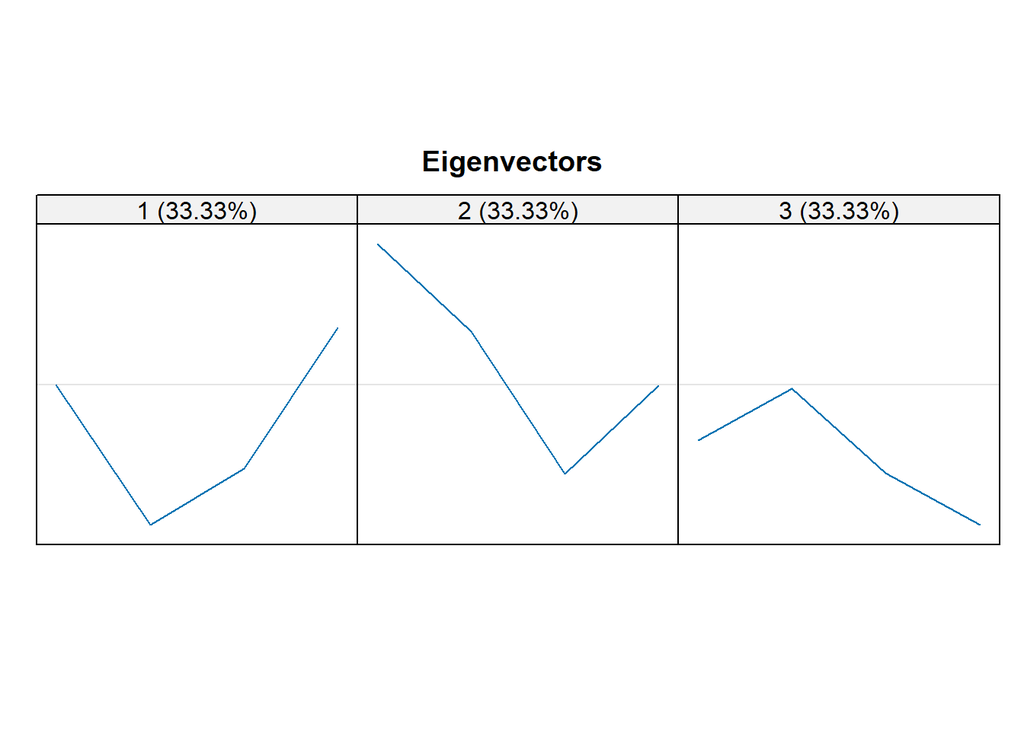

```r
plot(SSAWOutNoise, type='vectors', idx=1:3)
```

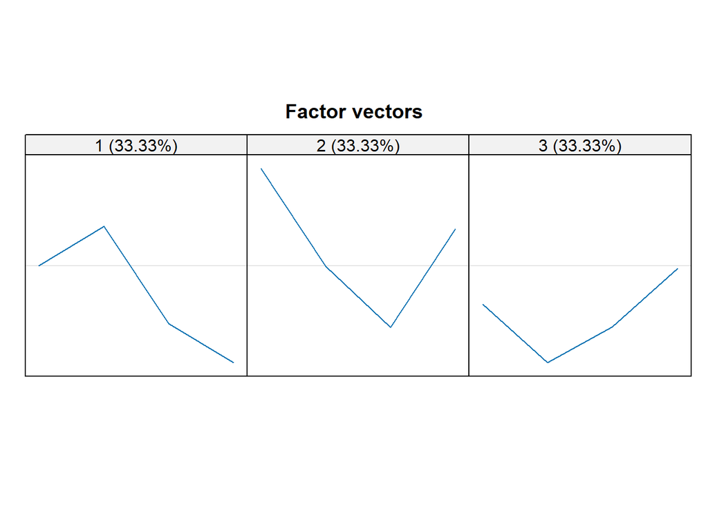

```r
plot(SSAWOutNoise, type='vectors', vectors='factor', idx=1:3)
```

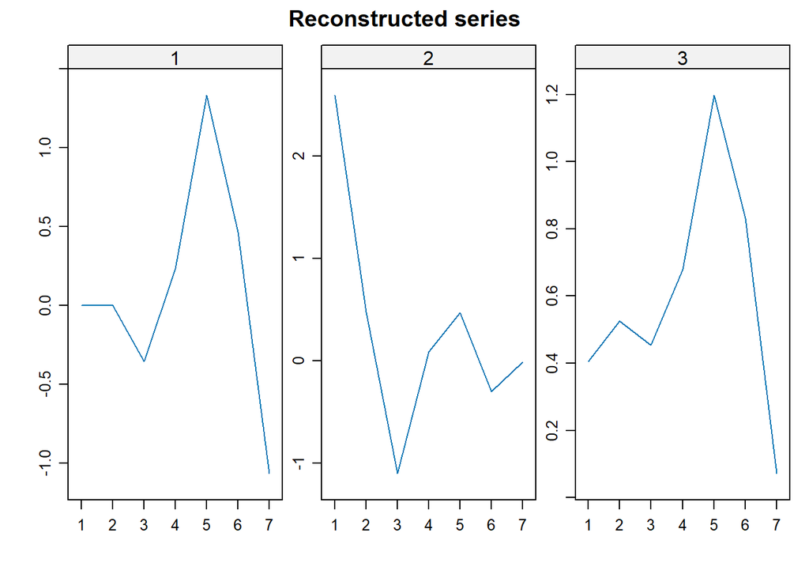

```r
plot(SSAWOutNoise, type='series', groups=1:3)
```

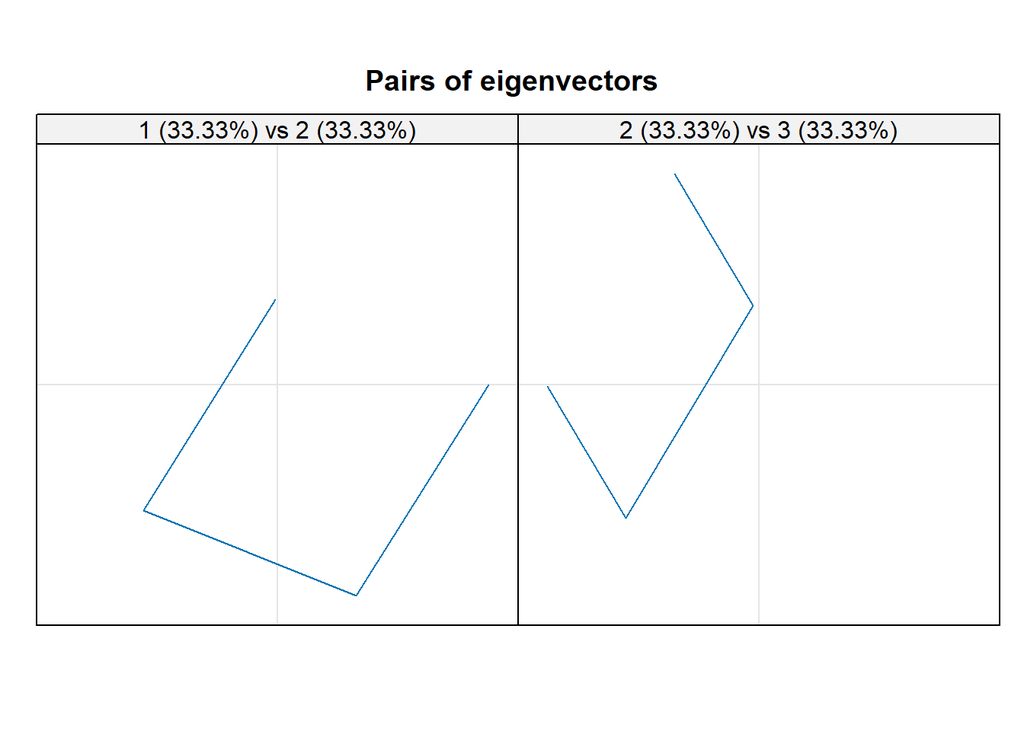

```r
plot(SSAWOutNoise, type='paired', idx=1:2)
```

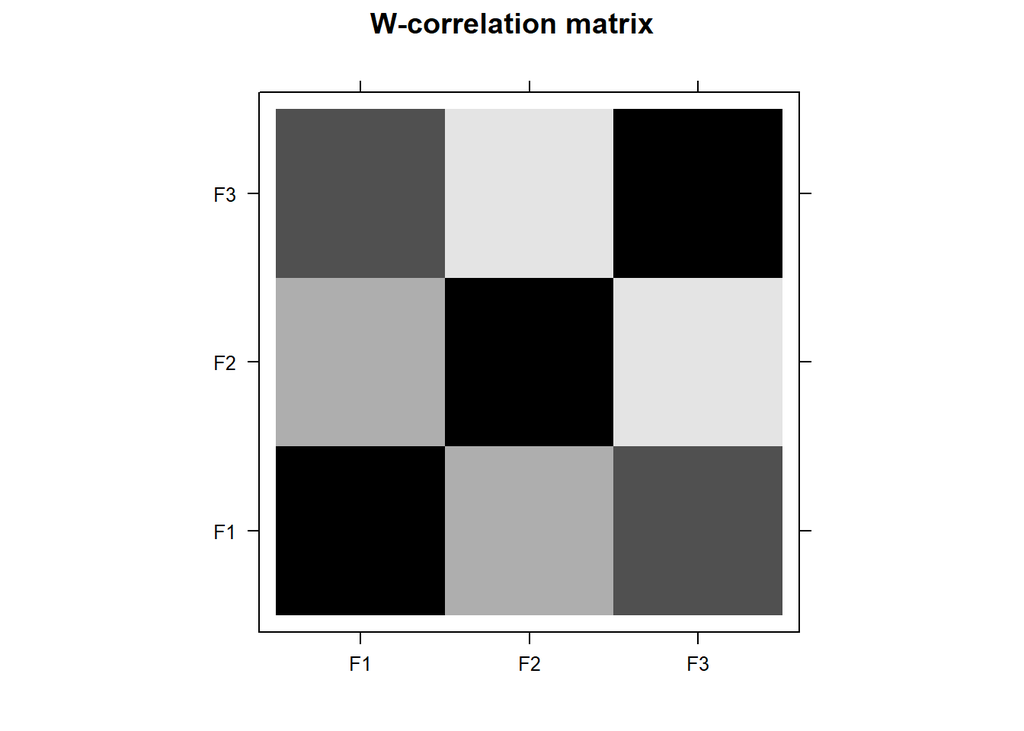

```r
plot(wcor(SSAWOutNoise, groups=1:3), scales=list(c(1,2,3)))
```

Графически, в случае слабой разделимости, вместо константного ряда получается ряд, напоминающий периодический, из-за чего разделить и определить компоненты ряда становится невозможным.

Если же, например, изменить коэффициент в периодическом ряде, то все компоненты можно легко разделить.

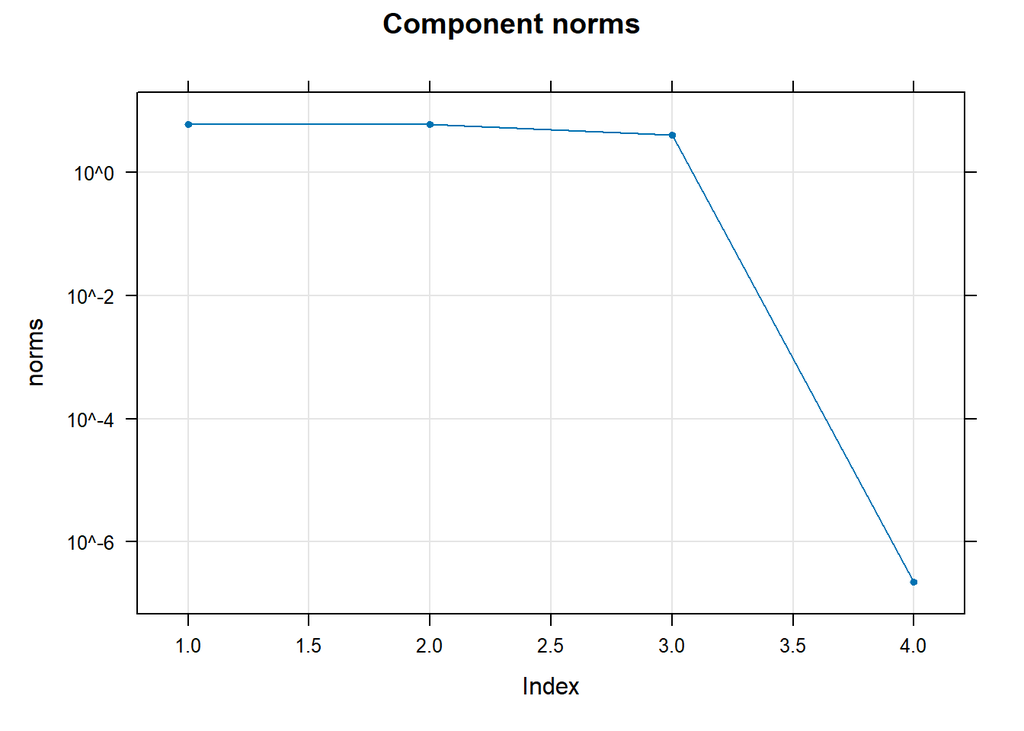

```r
PeriodicTS_New <- CreateExponentialTimeSeries(3, 0, 1/4, 0, 7)
TSAWOutNoise_New <- PeriodicTS_New + ConstTS
SSAWOutNoise_New <- ssa(TSAWOutNoise_New)

plot(SSAWOutNoise_New)
```

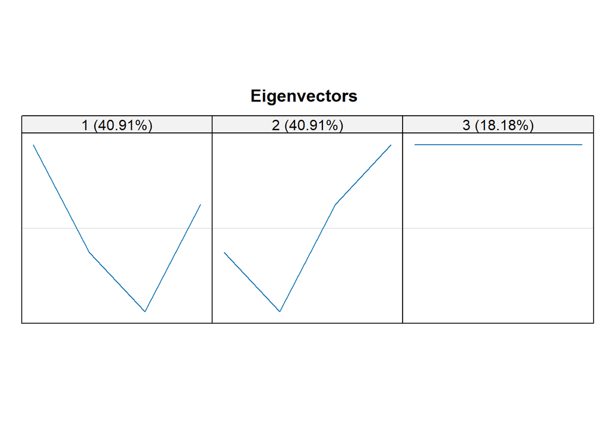

```r
plot(SSAWOutNoise_New, type='vectors', idx=1:3)
```

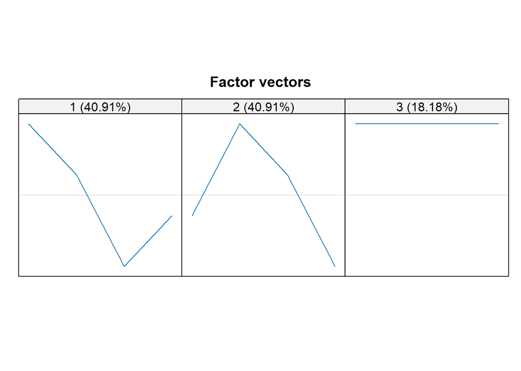

```r
plot(SSAWOutNoise_New, type='vectors', vectors='factor', idx=1:3)
```

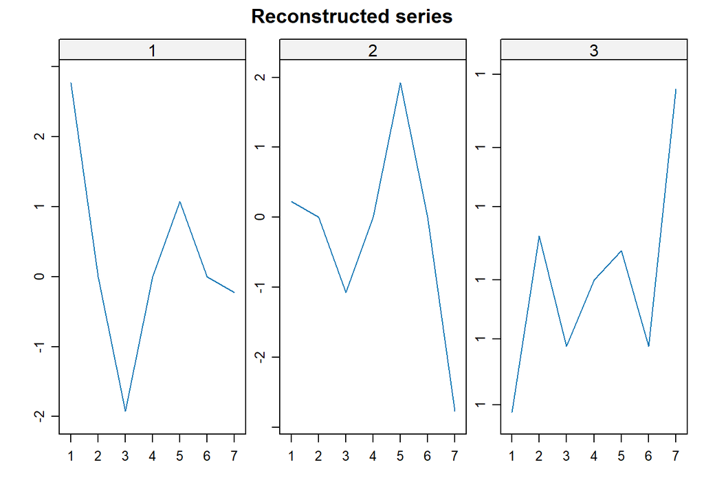

```r
plot(SSAWOutNoise_New, type='series', groups=1:3)
```

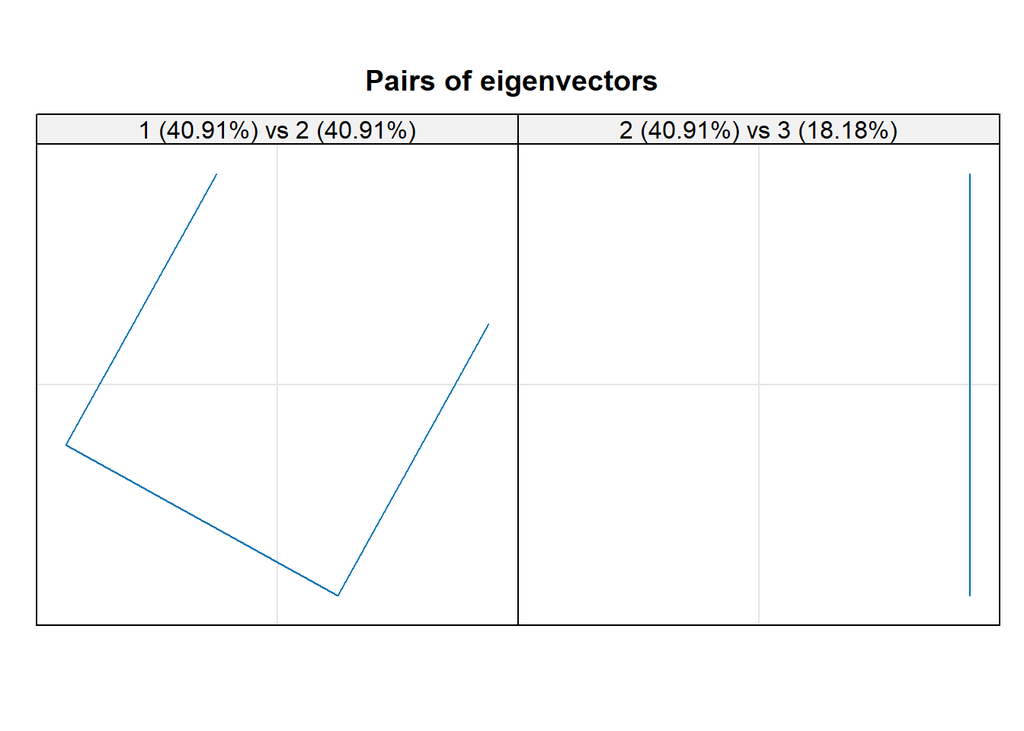

```r
plot(SSAWOutNoise_New, type='paired', idx=1:2)
```

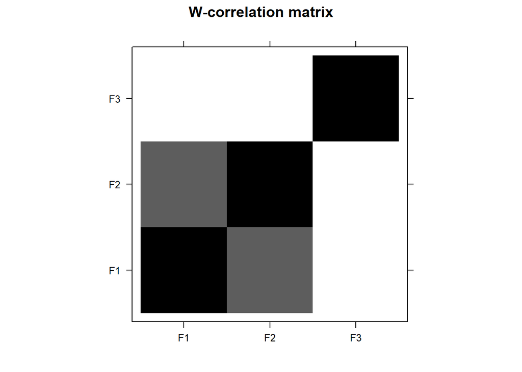

```r
plot(wcor(SSAWOutNoise_New, groups=1:3), scales=list(c(1,2,3)))
```

При добавление белого шума значения сингулярных чисел не совпадают друг с другом. Можно заметить возможность выделения тренда (константного ряда), периодики (ряда с косинусом) и шума (с самым низким сингулярным числом)

```r
samplenorm <- c(-0.2058265, -0.1471636, 0.6092870, 0.1220557, -0.2225760, -0.9239018, -0.3144127)
```

```r
TSWNoise <- TSWOutNoise + samplenorm
SSAWNoise <- ssa(TSWNoise)
TimeSeriesFiniteRank(TSWNoise)
```

```
## [1] 2 3 4
```

```
## [1] 4
```

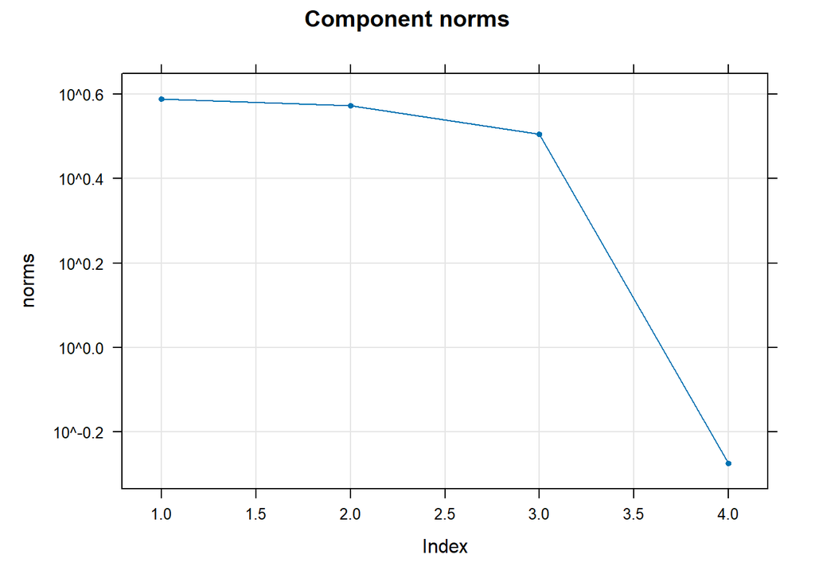

```r
plot(SSAWNoise)
```

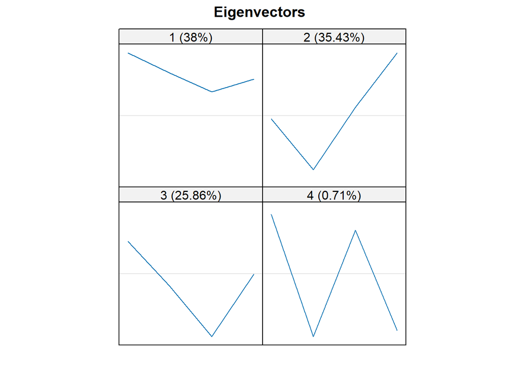

```r
plot(SSAWNoise, type='vectors', idx=1:4)
```

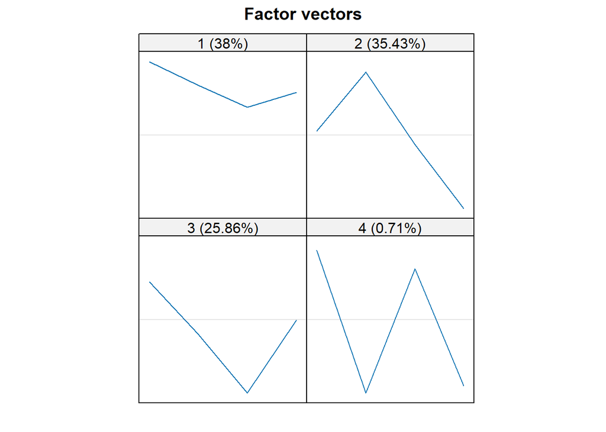

```r
plot(SSAWNoise, type='vectors', vectors='factor', idx=1:4)
```

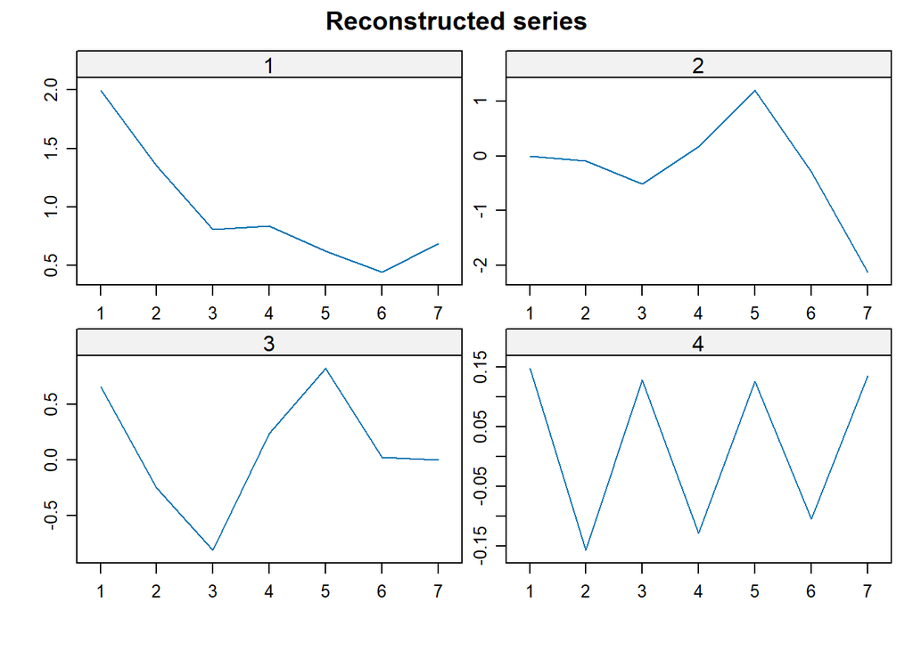

```r
plot(SSAWNoise, type='series', groups=1:4)
```

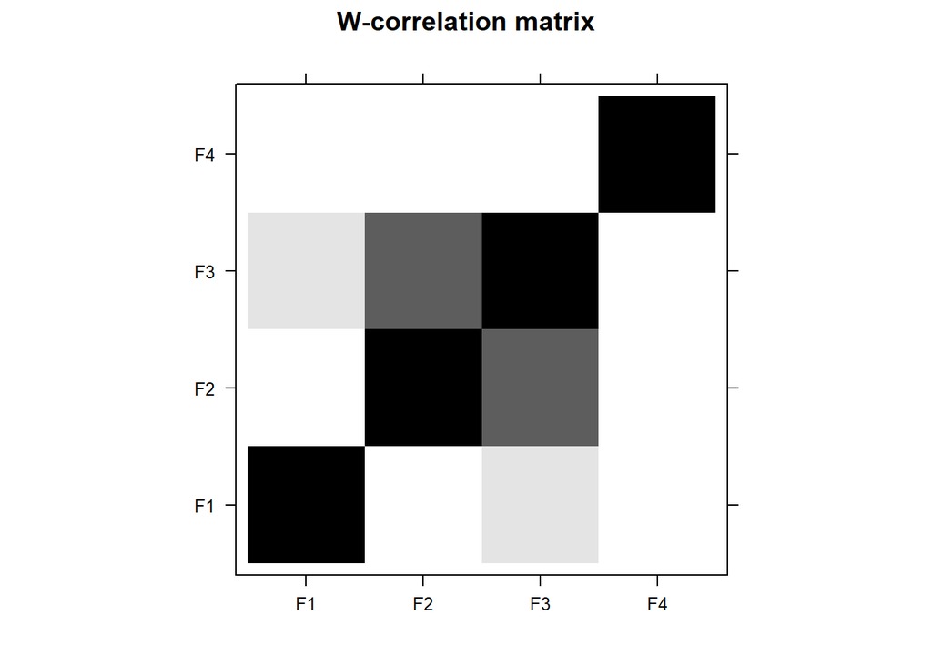

```r
plot(wcor(SSAWNoise, groups=1:4), scales=list(c(1,2,3,4)))
```

Продемонстрируем, что с ростом N точность выделения компонент ряда возрастает.

```r
PeriodicTS_Special <- CreateExponentialTimeSeries(3,0,1/4,0,1000)
ConstTS_Special <- rep(1, 1000)
samplenorm1000 <- rnorm(1000)
samplenorm1000[1:7] <- c(-0.2058265, -0.1471636, 0.6092870, 0.1220557, -0.2225760, -0.9239018, -0.3144127)
```

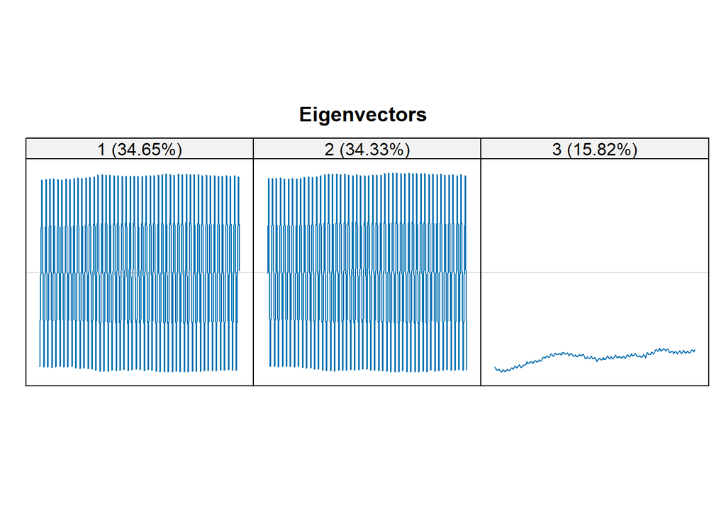

```r
TSExample <- PeriodicTS_Special+ConstTS_Special+samplenorm1000
# TimeSeriesFiniteRank(TSExample)
s.TSExample <- ssa(TSExample[1:400])
r.TSExample <- reconstruct(s.TSExample)
plot(s.TSExample, type='vectors', idx=1:3)
```

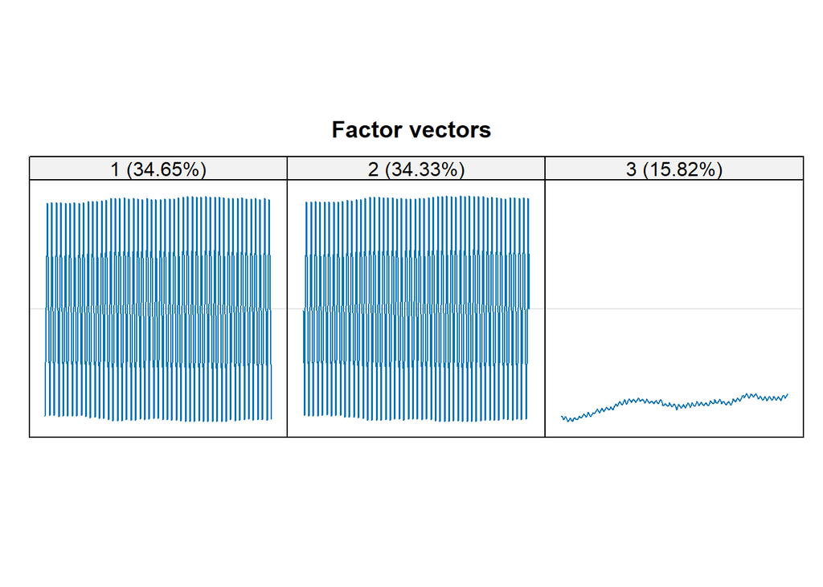

```r
plot(s.TSExample, type='vectors', vectors='factor', idx=1:3)
```

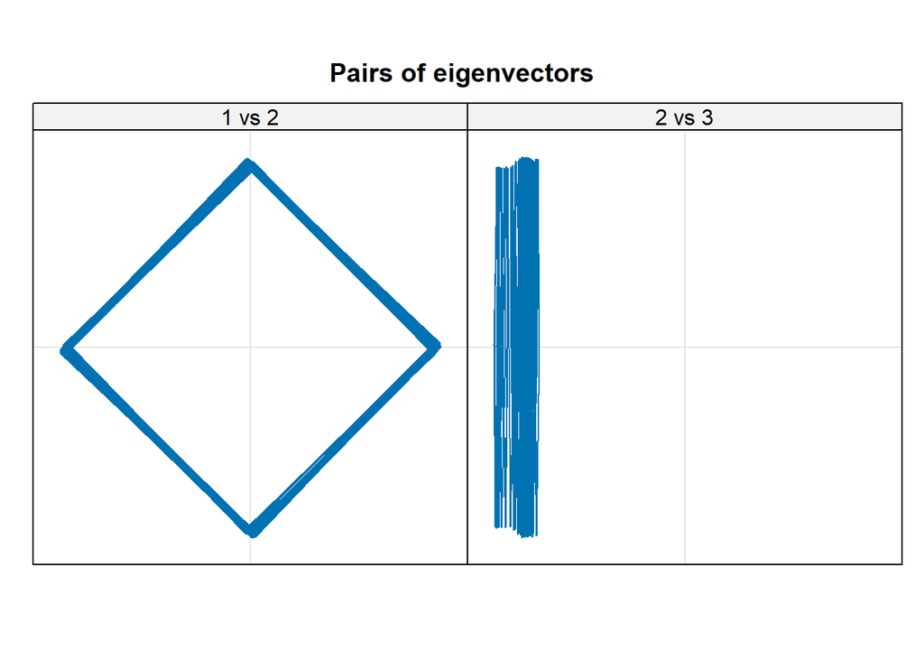

```r
plot(s.TSExample, type='paired', idx=1:2, plot.contrib = FALSE)
```

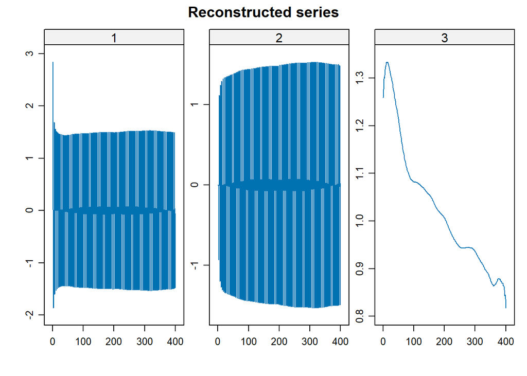

```r
plot(s.TSExample, type='series', groups=1:3)
```

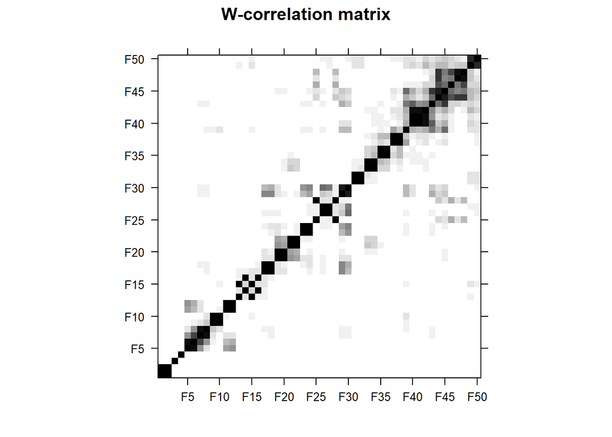

```r
plot(wcor(s.TSExample, groups=1:50), scales=list(at=seq(5, 50, 5)))
```

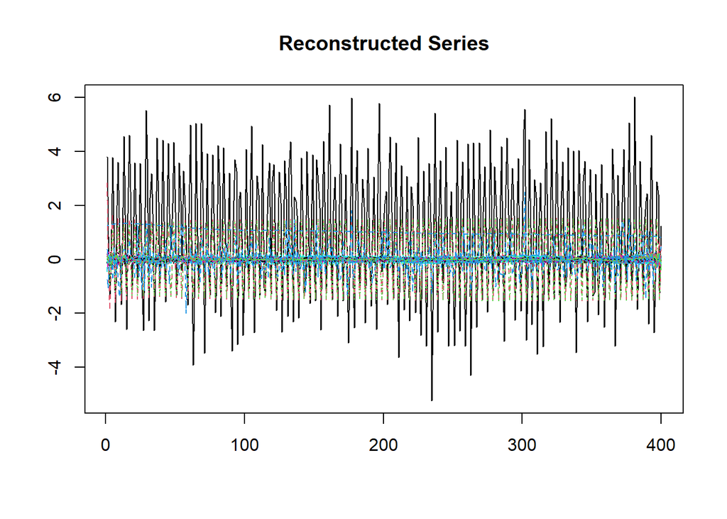

```r
plot(r.TSExample)
```

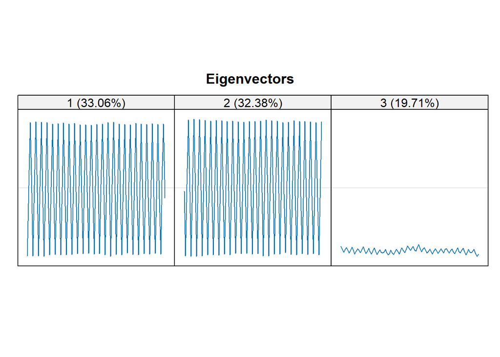

```r
s.TSExample <- ssa(TSExample[1:200])
r.TSExample <- reconstruct(s.TSExample)
plot(s.TSExample, type='vectors', idx=1:3)
```

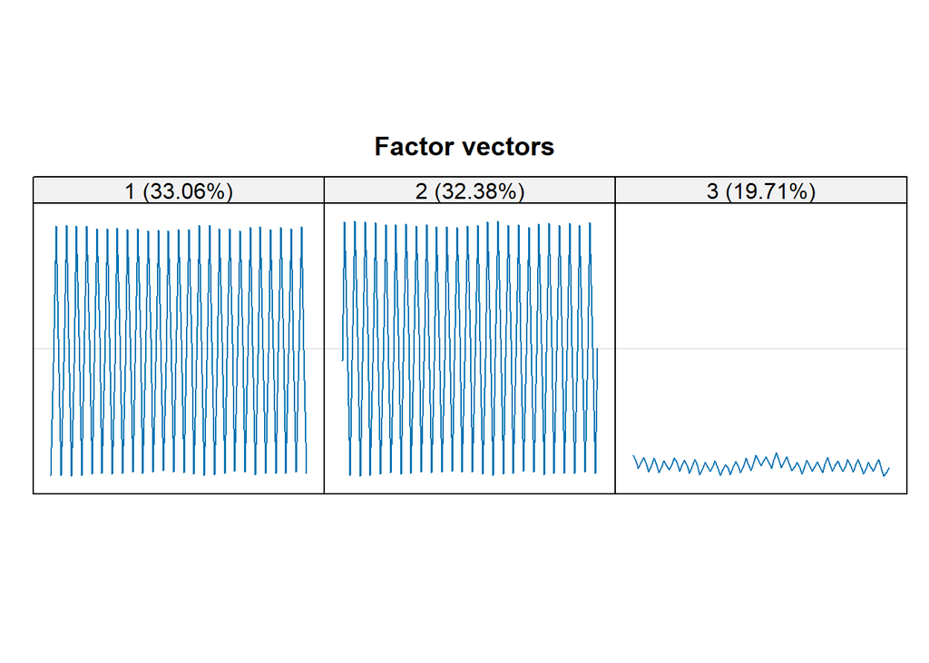

```r
plot(s.TSExample, type='vectors', vectors='factor', idx=1:3)
```

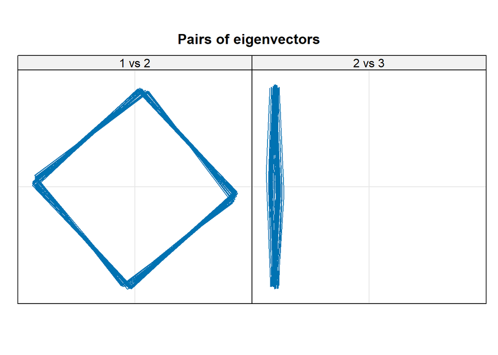

```r
plot(s.TSExample, type='paired', idx=1:2, plot.contrib = FALSE)
```

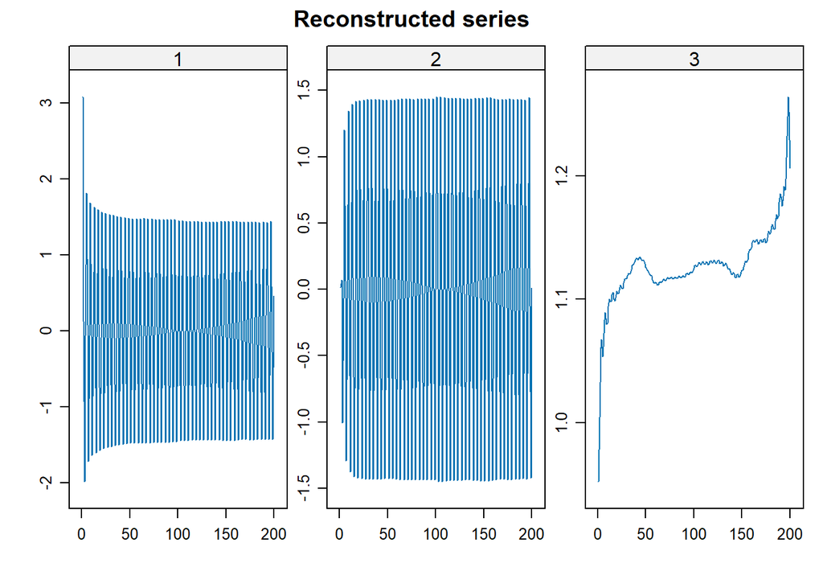

```r
plot(s.TSExample, type='series', groups=1:3)
```

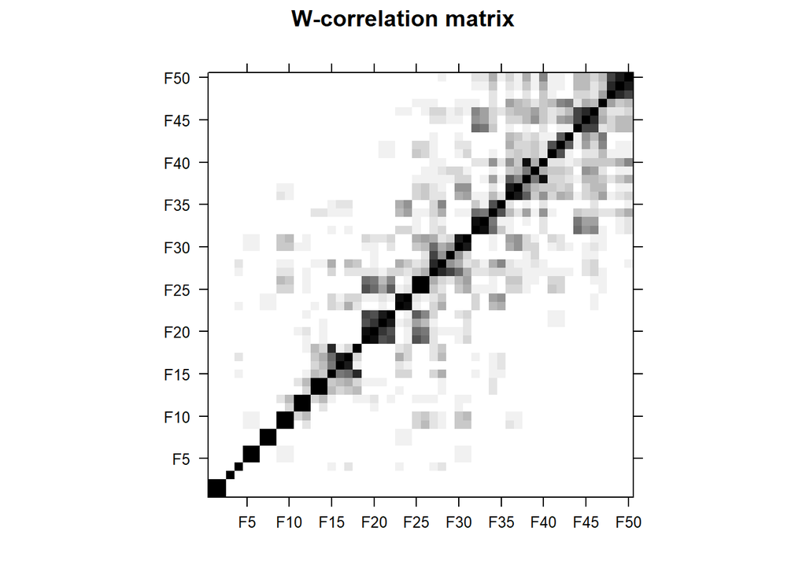

```r
plot(wcor(s.TSExample, groups=1:50), scales=list(at=seq(5,50,5)))
```

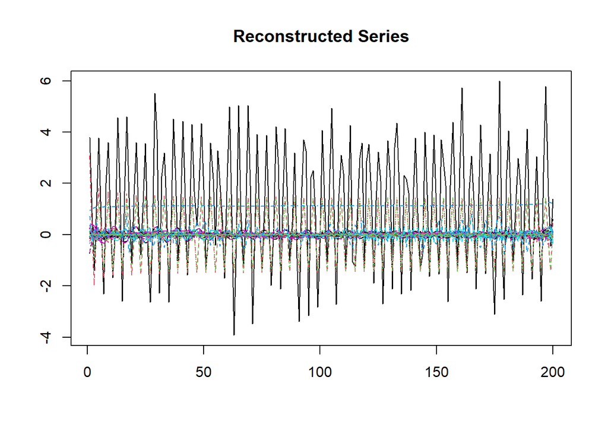

```r
plot(r.TSExample)
```